# Confidence Interval for a Population Mean

Yuanting Lu

11/18/2022

### Point Estimator

The sample mean $\bar{x}$ is a **point estimator** for the true population mean $\mu$.

### Interval Estimator

#### With Known $\sigma$

If the population standard deviation, $\sigma$, is known, a $100(1-\alpha)$% confidence interval for a population mean $\mu$ is
$$\left(\bar{x} - z_{\alpha/2}\dfrac{\sigma}{\sqrt
n}, \quad\bar{x} + z_{\alpha/2}\dfrac{\sigma}{\sqrt
n}\right).$$

**Book Example 8.5 and 8.6** Suppose that if a signal having intensity $\mu$ originates at location A, then the intensity recorded at location B is normally distributed with mean $\mu$ and standard deviation 3. That is, due to “noise,” the intensity recorded differs from the actual intensity of the signal by an amount that is normal with mean 0 and standard deviation 3. To reduce the error, the same signal is independently recorded 10 times. If the successive recorded values are
$$17, 21, 20,
18, 19, 22, 20, 21, 16, 19.$$

1. Construct a 90 percent confidence interval for $\mu$, the actual intensity.
2. Construct a 95 percent confidence interval for $\mu$, the actual intensity.
3. Construct a 99 percent confidence interval for $\mu$, the actual intensity.

**Book Example 8.8–8.11** From past experience it is known that the weights of salmon grown at a commercial hatchery are normal with a mean that varies from season to season but with a standard deviation that remains fixed at 0.3 pounds.

1. If a sample of 50 salmon yields an average weight of 5.6 pounds, find the 95% confidence interval for the true average weight of all salmon at this commercial hatchery.
2. If we want to be 90% certain that our estimate of the mean weight of a salmon is correct to within $\pm 0.1$ pounds (the **margin of error** is 0.1), how large a sample is needed?
3. What if we want to be 99% certain, how large a sample is needed?

#### With Unknown $\sigma$

If the population standard deviation, $\sigma$, is unknown, a $100(1-\alpha)$% confidence interval for a population mean $\mu$ is
$$\left(\bar{x} - t_{n-1, \alpha/2}\dfrac{s}{\sqrt
n}, \quad\bar{x} + t_{n-1, \alpha/2}\dfrac{s}{\sqrt
n}\right),$$

where $s$ is the sample standard deviation.

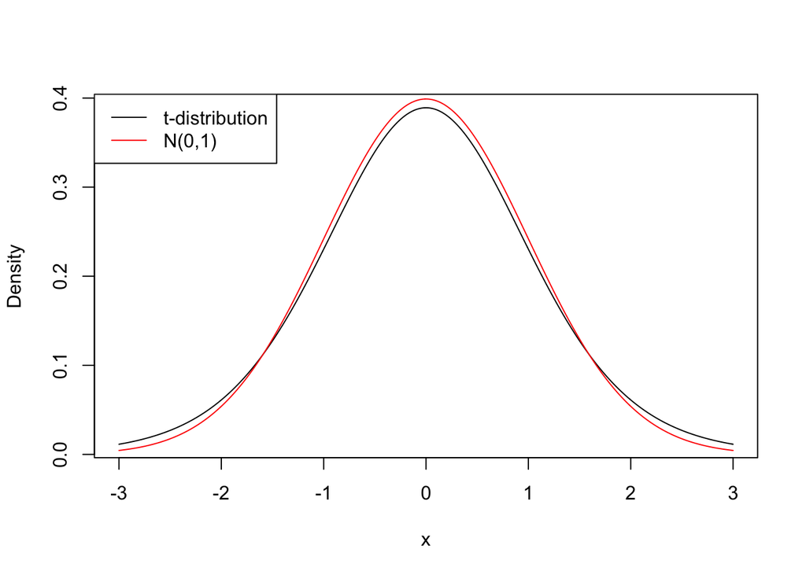

**Book Example 8.13** The Environmental Protection Agency (EPA) is concerned about the amounts of PCB, a toxic chemical, in the milk of nursing mothers. In a sample of 20 women, the amounts (in parts per million) of PCB were as follows:
$$16, 0, 0, 2, 3, 6, 8, 2, 5, 0, 12, 10, 5, 7, 2,
3, 8, 17, 9, 1$$
Use these data to obtain a

1. 95 percent confidence interval of the average amount of PCB in the milk of nursing mothers.
2. 99 percent confidence interval of the average amount of PCB in the milk of nursing mothers.